# Importancia de los sistemas de referencia de coordenadas en ecología

Ejemplo con localizaciones de muestreo simuladas

# 1 Objetivos

Este ejemplo introduce cuatro recomendaciones para trabajar con datos espaciales en ecología:

Cuatro recomendaciones:

1. Elegir un sistema de referencia de coordenadas (SRC) adecuado para la zona de estudio y los análisis que se van a realizar.
2. Documentar siempre el SRC empleado, preferiblemente indicando su código EPSG para garantizar la reproducibilidad del trabajo.
3. Evaluar las consecuencias de las transformaciones entre SRC, ya que pueden introducir distorsiones o afectar a la precisión de los resultados.
4. Tener en cuenta el efecto de la resolución espacial de los datos en función de la escala y objetivos del estudio, especialmente al integrar información procedente de distintas fuentes o escalas.

# 2 Carga de paquetes y simulación y representación de los datos

El siguiente bloque carga los paquetes y configura el mapa base de las visualizaciones interactivas.

```r
# Ejecutar una vez si pacman no está instalado
if(!("pacman" %in% installed.packages())) install.packages("pacman")

pacman::p_load( sf,
                # Representar, manipular, analizar y visualizar datos vectoriales espaciales
                # (puntos, líneas y polígonos)
                terra,
                # Herramientas para trabajar con datos espaciales (raster y vectoriales):
                # lectura, procesamiento, análisis, visualización...
                tidyterra,
                # objetos de terra con la filosofía del tidyverse
                maptiles,
                # descargar y utilizar mapas base (basemaps) de distintos
                # proveedores cartográficos
                tidyverse,
                # Conjunto de paquetes para la importación, transformación,
                # análisis y visualización
                mapview,
                # Visualizar de forma rápida e interactiva datos espaciales
                # (vectores y rásteres) en mapas explorables dentro de R
                viridis,
                # Paletas de colores
                patchwork
                # Combinar y organizar múltiples gráficos de ggplot2 en una única figura
)

# Configurar mapa base
mapview::mapviewOptions(basemaps = "OpenStreetMap.DE")
```

## 2.1 Localizaciones de muestreo

Vamos a crear una base de datos (totalmente inventados) de riqueza de especies en ocho parcelas en Sevilla.

```r
# Crear datos simulados
muestreos <- data.frame(
  parcela = paste0("P", 1:8),
  longitud = c(-5.984, -5.932, -5.894, -5.847,
               -5.795, -5.755, -5.710, -5.670),
  latitud = c(37.389, 37.425, 37.365, 37.455,
              37.395, 37.495, 37.430, 37.470),
  riqueza = c(12, 18, 9, 21, 15, 25, 17, 13))


# Revisar datos
print(muestreos, digits = 4, row.names = FALSE)
```

```
 parcela longitud latitud riqueza
      P1   -5.984   37.39      12
      P2   -5.932   37.42      18
      P3   -5.894   37.37       9
      P4   -5.847   37.45      21
      P5   -5.795   37.40      15
      P6   -5.755   37.49      25
      P7   -5.710   37.43      17
      P8   -5.670   37.47      13
```

## 2.2 Crear un objeto espacial

Convertimos la tabla en un objeto geográfico (`sf`). El código EPSG:4326 identifica WGS84 con coordenadas geográficas.

```r
# Convertir la tabla en un objeto espacial
muestreos_wgs84 <- muestreos |>
  st_as_sf(
    coords = c("longitud", "latitud"),
    crs = 4326)

print(muestreos_wgs84)
```

```
Simple feature collection with 8 features and 2 fields
Geometry type: POINT
Dimension:     XY
Bounding box:  xmin: -5.984 ymin: 37.365 xmax: -5.67 ymax: 37.495
Geodetic CRS:  WGS 84
  parcela riqueza              geometry
1      P1      12 POINT (-5.984 37.389)
2      P2      18 POINT (-5.932 37.425)
3      P3       9 POINT (-5.894 37.365)
4      P4      21 POINT (-5.847 37.455)
5      P5      15 POINT (-5.795 37.395)
6      P6      25 POINT (-5.755 37.495)
7      P7      17   POINT (-5.71 37.43)
8      P8      13   POINT (-5.67 37.47)
```

Distinguimos que es un objeto espacial porque ahora tiene una geometría asociada (en este caso de tipo punto) y un Sistema de Referencia de Coordenadas (SRC). Para estar seguros que el SRC está bien asignado y que los puntos representan nuestra zona de estudio siemre es conveniente representarlo. Para ello es una buena alternativa usar QGIS, que está preparado para la visualización, pero también lo podemos hacer en R.

[figure not shown]

```r
# Mapa base

osm <- get_tiles(muestreos_wgs84, provider = "OpenStreetMap", crop = TRUE)

location_map <- ggplot() +

  geom_spatraster_rgb(data = osm) +

  geom_sf(data = muestreos_wgs84,
          colour = "red",
          size = 3)

plot(location_map)
```

# 3 Recomendación (1): Elegir un sistema de referencia de coordenadas (SRC) adecuado para la zona de estudio y los análisis que se van a realizar

Una de los aspectos más importantes cuando trabajamos con datos geográficos y, por tanto, con Sistmas de Referencia de Coordenadas (SRC) es elegir un SRC adecuado según la localización y extensión de nuestra área de estudio. Algunas recomendaciones, se pueden encontrar en: https://datos.gob.es/sites/default/files/doc/file/guia_publicacion_datos_espaciales_1.pdf.

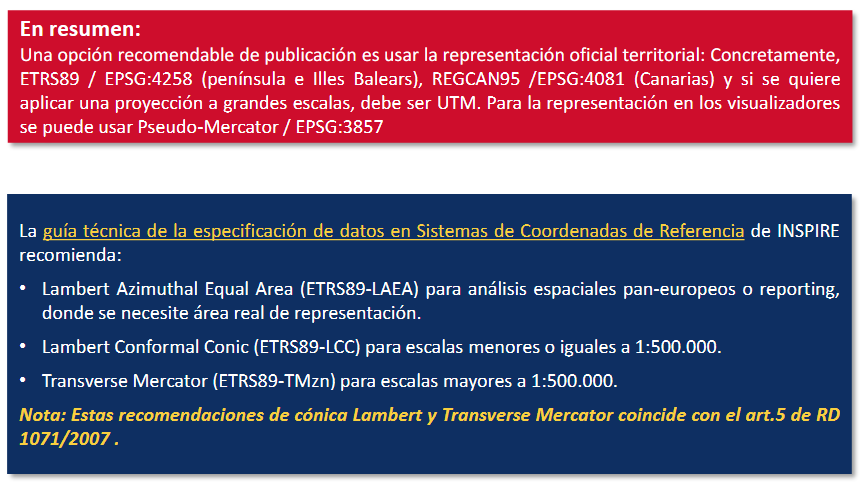

.

## 3.1 ¿Como puede afectar el SRC al cálculo de distancias?

Para ver como puede afectar la elección del SRC en el cálculo de distancias, vamos a comprar las distanacias entre parcelas con los datos en diferentes SRC:

- EPSG:4326 SRC geográfico global. Sus coordenadas se expresan en grados. Es el sistema nativo del GPS y el estándar por defecto en algunos formatos web.
- EPSG:25830 ETRS89 / UTM zona 30N (SRC proyectado). Es el sistema oficial de cartografía y geolocalización en España para la producción de mapas topográficos y datos geográficos estándar de la zona centro Peninsular.
- EPSG:3857 WGS 84 / Pseudo-Mercator. Se utiliza habitualmente para visualización web (Open Street Maps, Google Maps etc), pero no es recomendable para mediciones precisas de superficies o distancias.

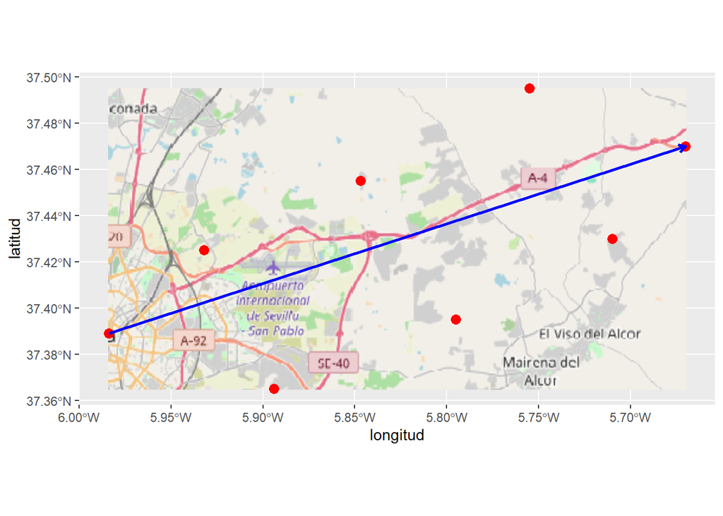

```r
# Coordenadas de P1 y P8
p1 <- st_coordinates(muestreos_wgs84[muestreos_wgs84$parcela == "P1", ])
p8 <- st_coordinates(muestreos_wgs84[muestreos_wgs84$parcela == "P8", ])

location_map_dist <- ggplot() +

  geom_spatraster_rgb(data = osm) +

  geom_sf(
    data = muestreos_wgs84,
    colour = "red",
    size = 3
  )+

  geom_segment(
    aes(
      x    = p1[1],
      y    = p1[2],
      xend = p8[1],
      yend = p8[2]
    ),
    colour = "blue",
    linewidth = 1,
    arrow = arrow(length = unit(0.2, "cm"))
  ) +
  labs(x="longitud", y="latitud")

location_map_dist
```

```r
# Transformamos los datos a diferentes a EPSG:25830 (UTM zona 30N) y a EPSG:3857 (pseudomercator)

muestreos_utm <- st_transform(muestreos_wgs84, 25830)
muestreos_mercator <- st_transform(muestreos_wgs84, 3857)

# Distancia entre la primera y la última parcela en coordenadas geográficas (WGS84)

distancia_geodesica <- st_distance(
  muestreos_wgs84[1, ],
  muestreos_wgs84[8, ]
)

# Distancia plana en un SRC local adecuado (ETRS89 proyectadas UTM zona 30Norte)

distancia_utm <- st_distance(
  muestreos_utm[1, ],
  muestreos_utm[8, ]
)

# Distancia plana calculada en Pseudo-Mercator.

distancia_mercator <- st_distance(
  muestreos_mercator[1, ],
  muestreos_mercator[8, ]
)

comparacion_distancias <- data.frame(
  metodo = c(
    "Geodésica en WGS 84",
    "Plana en ETRS89 / UTM 30N",
    "Plana en Web Mercator"
  ),
  distancia_km = c(
    as.numeric(distancia_geodesica),
    as.numeric(distancia_utm),
    as.numeric(distancia_mercator)
  ) / 1000
)

knitr::kable(
  comparacion_distancias,
  caption = "Comparación de distancias entre P1 y P8 según el sistema de referencia utilizados"
)
```

Comparación de distancias entre P1 y P8 según el sistema de referencia utilizados

| metodo | distancia_km |
| --- | --- |
| Geodésica en WGS 84 | 29.15249 |
| Plana en ETRS89 / UTM 30N | 29.22033 |
| Plana en Web Mercator | 36.75237 |

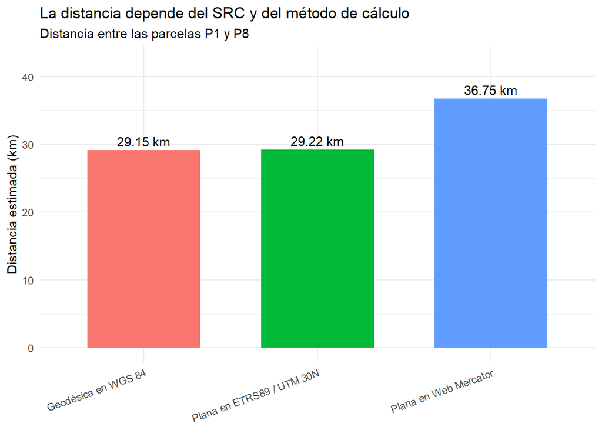

```r
ggplot(
  comparacion_distancias,
  aes(x = metodo, y = distancia_km, fill = metodo)
) +
  geom_col(width = 0.65, show.legend = FALSE) +
  geom_text(
    aes(label = sprintf("%.2f km", distancia_km)),
    vjust = -0.4
  ) +
  labs(
    title = "La distancia depende del SRC y del método de cálculo",
    subtitle = "Distancia entre las parcelas P1 y P8",
    x = NULL,
    y = "Distancia estimada (km)"
  ) +
  coord_cartesian(
    ylim = c(0, max(comparacion_distancias$distancia_km) * 1.15)
  ) +
  theme_minimal() +
  theme(
    axis.text.x = element_text(angle = 20, hjust = 1)
  )
```

## 3.2 ¿Como puede afectar el SRC al cálculo de superficies?

Al igual que el SRC influye en el cálculo de distancias, también influye en el cálculo de superficies

```r
#Crear un área de influencia de 1 km alrededor de cada parcela.
# Para hacer un buffer de una distancia conocida se utiliza el
# SRC proyectado local EPSG:25830, cuyas unidades son metros.

buffers_utm <- st_buffer(muestreos_utm, dist = 1000)

# Superficie de los buffers.

buffers_utm$area_ha <- as.numeric(st_area(buffers_utm)) / 10000

# Crear los mismos buffers directamente en Web Mercator.

buffers_mercator <- st_buffer(muestreos_mercator, dist = 1000)

# Transformarlos a UTM para comparar su superficie en un mismo SRC.

buffers_mercator_utm <- st_transform(buffers_mercator, 25830)

buffers_mercator_utm$area_ha <- (
  as.numeric(st_area(buffers_mercator_utm)) / 10000
)

comparacion_areas <- data.frame(
  parcela = buffers_utm$parcela,
  area_real_ha = (pi*1000^2)/10000,
  area_utm_ha = buffers_utm$area_ha,

  area_mercator_ha = buffers_mercator_utm$area_ha
) |>
  mutate(
    area_utm_ha_error = abs((area_real_ha-area_utm_ha)/area_real_ha)*100,
    area_mercator_ha_error = abs((area_real_ha-area_mercator_ha)/area_real_ha)*100)

knitr::kable(
  comparacion_areas,
  caption = "Comparación de áreas según el sistema de referencia utilizado"
)
```

Comparación de áreas según el sistema de referencia utilizado

| parcela | area_real_ha | area_utm_ha | area_mercator_ha | area_utm_ha_error | area_mercator_ha_error |
| --- | --- | --- | --- | --- | --- |
| P1 | 314.1593 | 314.0157 | 198.0624 | 0.0456863 | 36.95477 |
| P2 | 314.1593 | 314.0157 | 197.8617 | 0.0456863 | 37.01866 |
| P3 | 314.1593 | 314.0157 | 198.1681 | 0.0456863 | 36.92113 |
| P4 | 314.1593 | 314.0157 | 197.6855 | 0.0456863 | 37.07475 |
| P5 | 314.1593 | 314.0157 | 197.9892 | 0.0456863 | 36.97808 |
| P6 | 314.1593 | 314.0157 | 197.4559 | 0.0456863 | 37.14784 |
| P7 | 314.1593 | 314.0157 | 197.7877 | 0.0456863 | 37.04222 |
| P8 | 314.1593 | 314.0157 | 197.5696 | 0.0456863 | 37.11165 |

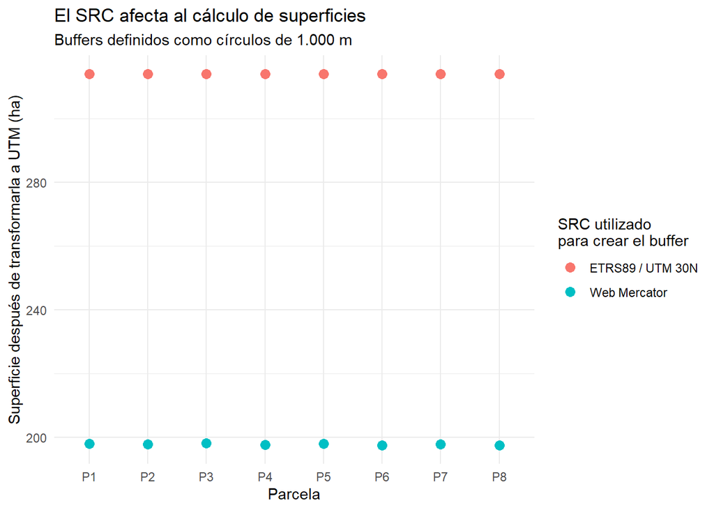

```r
ggplot(
  comparacion_areas,
  aes(x = parcela)
) +
  geom_point(
    aes(y = area_utm_ha, colour = "ETRS89 / UTM 30N"),
    size = 3
  ) +
  geom_point(
    aes(y = area_mercator_ha, colour = "Web Mercator"),
    size = 3
  ) +
  labs(
    title = "El SRC afecta al cálculo de superficies",
    subtitle = "Buffers definidos como círculos de 1.000 m",
    x = "Parcela",
    y = "Superficie después de transformarla a UTM (ha)",
    colour = "SRC utilizado\npara crear el buffer"
  ) +
  theme_minimal()
```

# 4 Recomendación (2): Documentar siempre el SRC empleado, preferiblemente indicando su código EPSG para garantizar la reproducibilidad del trabajo.

EL código EPSG es un identificador numérico único que define un Sistema de Referencia de Coordendas (SRC). Es un código abreviado que agrupa elipsoide, datum y proyección cartográfica.

## 4.1 ¿Cómo lo reportamos?

```r
# Información resumida.

st_crs(muestreos_wgs84)
```

```
Coordinate Reference System:
  User input: EPSG:4326
  wkt:
GEOGCRS["WGS 84",
    ENSEMBLE["World Geodetic System 1984 ensemble",
        MEMBER["World Geodetic System 1984 (Transit)"],
        MEMBER["World Geodetic System 1984 (G730)"],
        MEMBER["World Geodetic System 1984 (G873)"],
        MEMBER["World Geodetic System 1984 (G1150)"],
        MEMBER["World Geodetic System 1984 (G1674)"],
        MEMBER["World Geodetic System 1984 (G1762)"],
        MEMBER["World Geodetic System 1984 (G2139)"],
        MEMBER["World Geodetic System 1984 (G2296)"],
        ELLIPSOID["WGS 84",6378137,298.257223563,
            LENGTHUNIT["metre",1]],
        ENSEMBLEACCURACY[2.0]],
    PRIMEM["Greenwich",0,
        ANGLEUNIT["degree",0.0174532925199433]],
    CS[ellipsoidal,2],
        AXIS["geodetic latitude (Lat)",north,
            ORDER[1],
            ANGLEUNIT["degree",0.0174532925199433]],
        AXIS["geodetic longitude (Lon)",east,
            ORDER[2],
            ANGLEUNIT["degree",0.0174532925199433]],
    USAGE[
        SCOPE["Horizontal component of 3D system."],
        AREA["World."],
        BBOX[-90,-180,90,180]],
    ID["EPSG",4326]]
```

```r
st_crs(muestreos_utm)
```

```
Coordinate Reference System:
  User input: EPSG:25830
  wkt:
PROJCRS["ETRS89 / UTM zone 30N",
    BASEGEOGCRS["ETRS89",
        ENSEMBLE["European Terrestrial Reference System 1989 ensemble",
            MEMBER["European Terrestrial Reference Frame 1989"],
            MEMBER["European Terrestrial Reference Frame 1990"],
            MEMBER["European Terrestrial Reference Frame 1991"],
            MEMBER["European Terrestrial Reference Frame 1992"],
            MEMBER["European Terrestrial Reference Frame 1993"],
            MEMBER["European Terrestrial Reference Frame 1994"],
            MEMBER["European Terrestrial Reference Frame 1996"],
            MEMBER["European Terrestrial Reference Frame 1997"],
            MEMBER["European Terrestrial Reference Frame 2000"],
            MEMBER["European Terrestrial Reference Frame 2005"],
            MEMBER["European Terrestrial Reference Frame 2014"],
            MEMBER["European Terrestrial Reference Frame 2020"],
            ELLIPSOID["GRS 1980",6378137,298.257222101,
                LENGTHUNIT["metre",1]],
            ENSEMBLEACCURACY[0.1]],
        PRIMEM["Greenwich",0,
            ANGLEUNIT["degree",0.0174532925199433]],
        ID["EPSG",4258]],
    CONVERSION["UTM zone 30N",
        METHOD["Transverse Mercator",
            ID["EPSG",9807]],
        PARAMETER["Latitude of natural origin",0,
            ANGLEUNIT["degree",0.0174532925199433],
            ID["EPSG",8801]],
        PARAMETER["Longitude of natural origin",-3,
            ANGLEUNIT["degree",0.0174532925199433],
            ID["EPSG",8802]],
        PARAMETER["Scale factor at natural origin",0.9996,
            SCALEUNIT["unity",1],
            ID["EPSG",8805]],
        PARAMETER["False easting",500000,
            LENGTHUNIT["metre",1],
            ID["EPSG",8806]],
        PARAMETER["False northing",0,
            LENGTHUNIT["metre",1],
            ID["EPSG",8807]]],
    CS[Cartesian,2],
        AXIS["(E)",east,
            ORDER[1],
            LENGTHUNIT["metre",1]],
        AXIS["(N)",north,
            ORDER[2],
            LENGTHUNIT["metre",1]],
    USAGE[
        SCOPE["Engineering survey, topographic mapping."],
        AREA["Europe between 6°W and 0°W: Faroe Islands offshore; Ireland - offshore; Jan Mayen - offshore; Norway including Svalbard - offshore; Spain - mainland - onshore and offshore."],
        BBOX[35.26,-6,80.49,0.01]],
    USAGE[
        SCOPE["Pan-European conformal mapping at scales larger than 1:500,000."],
        AREA["Europe between 6°W and 0°W and approximately 35°15'N to 80°30'N."],
        BBOX[35.26,-6.01,80.49,0]],
    ID["EPSG",25830]]
```

```r
st_crs(muestreos_mercator)
```

```
Coordinate Reference System:
  User input: EPSG:3857
  wkt:
PROJCRS["WGS 84 / Pseudo-Mercator",
    BASEGEOGCRS["WGS 84",
        ENSEMBLE["World Geodetic System 1984 ensemble",
            MEMBER["World Geodetic System 1984 (Transit)"],
            MEMBER["World Geodetic System 1984 (G730)"],
            MEMBER["World Geodetic System 1984 (G873)"],
            MEMBER["World Geodetic System 1984 (G1150)"],
            MEMBER["World Geodetic System 1984 (G1674)"],
            MEMBER["World Geodetic System 1984 (G1762)"],
            MEMBER["World Geodetic System 1984 (G2139)"],
            MEMBER["World Geodetic System 1984 (G2296)"],
            ELLIPSOID["WGS 84",6378137,298.257223563,
                LENGTHUNIT["metre",1]],
            ENSEMBLEACCURACY[2.0]],
        PRIMEM["Greenwich",0,
            ANGLEUNIT["degree",0.0174532925199433]],
        ID["EPSG",4326]],
    CONVERSION["Popular Visualisation Pseudo-Mercator",
        METHOD["Popular Visualisation Pseudo Mercator",
            ID["EPSG",1024]],
        PARAMETER["Latitude of natural origin",0,
            ANGLEUNIT["degree",0.0174532925199433],
            ID["EPSG",8801]],
        PARAMETER["Longitude of natural origin",0,
            ANGLEUNIT["degree",0.0174532925199433],
            ID["EPSG",8802]],
        PARAMETER["False easting",0,
            LENGTHUNIT["metre",1],
            ID["EPSG",8806]],
        PARAMETER["False northing",0,
            LENGTHUNIT["metre",1],
            ID["EPSG",8807]]],
    CS[Cartesian,2],
        AXIS["easting (X)",east,
            ORDER[1],
            LENGTHUNIT["metre",1]],
        AXIS["northing (Y)",north,
            ORDER[2],
            LENGTHUNIT["metre",1]],
    USAGE[
        SCOPE["Web mapping and visualisation."],
        AREA["World between 85.06°S and 85.06°N."],
        BBOX[-85.06,-180,85.06,180]],
    ID["EPSG",3857]]
```

```r
# Obtener explícitamente códigos EPSG y nombres.

informacion_src <- data.frame(
  objeto = c(
    "Datos originales",
    "Datos para análisis local",
    "Datos en Web Mercator"
  ),
  nombre_src = c(
    st_crs(muestreos_wgs84)$Name,
    st_crs(muestreos_utm)$Name,
    st_crs(muestreos_mercator)$Name
  ),
  epsg = c(
    st_crs(muestreos_wgs84)$epsg,
    st_crs(muestreos_utm)$epsg,
    st_crs(muestreos_mercator)$epsg
  )
)

knitr::kable(informacion_src,
             caption = "Resumen nombre SRC y EPSG")
```

Resumen nombre SRC y EPSG

| objeto | nombre_src | epsg |
| --- | --- | --- |
| Datos originales | WGS 84 | 4326 |
| Datos para análisis local | ETRS89 / UTM zone 30N | 25830 |
| Datos en Web Mercator | WGS 84 / Pseudo-Mercator | 3857 |

## 4.2 ¿Y que pasa si no lo reportamos correctamente?

Ejemplo, se reporta que es ETRS89/UTM pero no la zona

```r
# Como no la sabemos asignamos una zona UTM incorrecta

#Generamos datos
muestreos_utm_zona_mal <- muestreos_utm
st_crs(muestreos_utm_zona_mal)<- NA #Datos de partida

# Mostramos datos (sin SRC)
muestreos_utm_zona_mal
```

```
Simple feature collection with 8 features and 2 fields
Geometry type: POINT
Dimension:     XY
Bounding box:  xmin: 235822.4 ymin: 4139294 xmax: 263881.7 ymax: 4153352
CRS:           NA
  parcela riqueza                 geometry
1      P1      12 POINT (235822.4 4142206)
2      P2      18 POINT (240551.5 4146057)
3      P3       9 POINT (243710.3 4139294)
4      P4      21 POINT (248175.3 4149156)
5      P5      15 POINT (252578.2 4142359)
6      P6      25 POINT (256444.6 4153352)
7      P7      17 POINT (260215.9 4146023)
8      P8      13 POINT (263881.7 4150361)
```

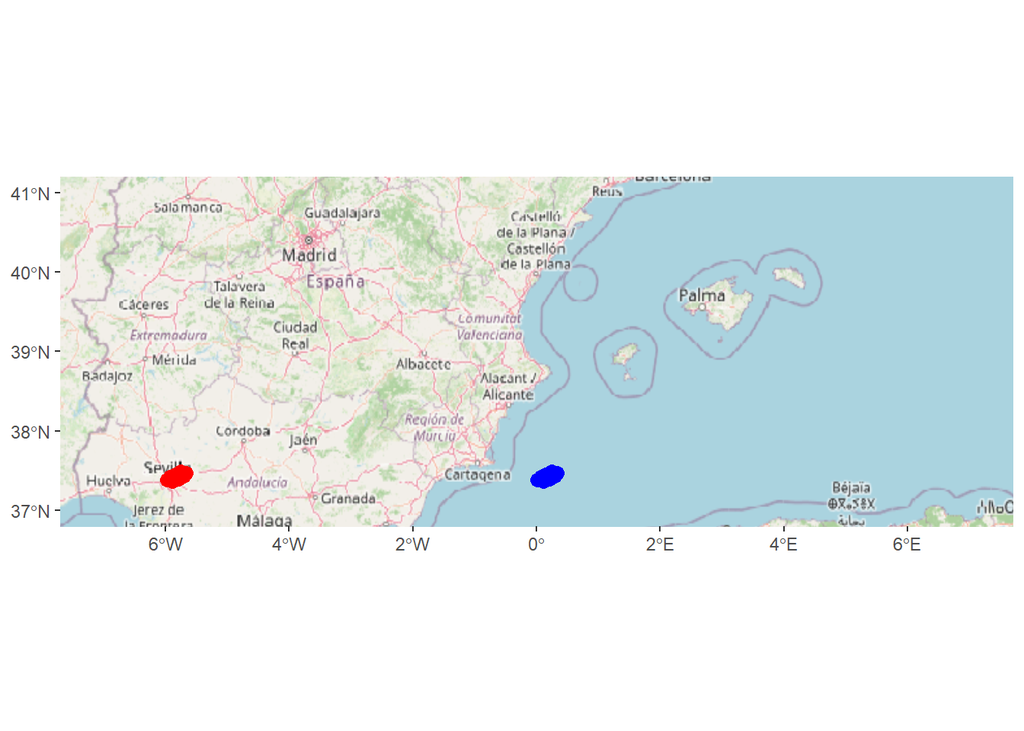

```r
#Como no sabemos la zona asignamos una de manera incorrecta
st_crs(muestreos_utm_zona_mal) <- 25831

bb <- st_bbox(c(
  xmin = -7,
  xmax = 7,
  ymin = 37,
  ymax = 41
), crs = st_crs(4326))

bb_sf <- st_as_sfc(bb)

osm <- get_tiles(bb_sf, provider = "OpenStreetMap")

osm<-get_tiles(bb, provider = "OpenStreetMap")

ggplot() +

  geom_spatraster_rgb(data = osm) +

  geom_sf(data = muestreos_utm, colour = "red", size = 3) +
  geom_sf(data = muestreos_utm_zona_mal, colour = "blue", size = 3) +
  coord_sf(
    xlim = c(-7, 7),
    ylim = c(37, 41))
```

# 5 Recomendacion (3): Conocer las implicaciones de las transformaciones del SRC: las reproyecciones

## 5.1 Asignar vs. reproyectar

**Nota**

Asignar un SRC a un objeto espacial no implica reproyectarlo.

Asignar EPSG:25830 a unas coordenadas que realmente están en EPSG:4326 no implica reproyectar las coordenadas, simplemente modifica su metadata.

```r
# Asignar un SRC
muestreo_asignado <- muestreos_wgs84
st_crs(muestreo_asignado) <- 25830
print(muestreo_asignado)
```

```
Simple feature collection with 8 features and 2 fields
Geometry type: POINT
Dimension:     XY
Bounding box:  xmin: -5.984 ymin: 37.365 xmax: -5.67 ymax: 37.495
Projected CRS: ETRS89 / UTM zone 30N
  parcela riqueza              geometry
1      P1      12 POINT (-5.984 37.389)
2      P2      18 POINT (-5.932 37.425)
3      P3       9 POINT (-5.894 37.365)
4      P4      21 POINT (-5.847 37.455)
5      P5      15 POINT (-5.795 37.395)
6      P6      25 POINT (-5.755 37.495)
7      P7      17   POINT (-5.71 37.43)
8      P8      13   POINT (-5.67 37.47)
```

Fíjate en que, si asignamos un SRC proyectado (ETRS89 / UTM huso 30N, en metros) a unas coordenadas expresadas en un SRC geográfico (WGS84, en grados), el programa pasa a interpretar como metros unos valores que representan grados. Como consecuencia, las parcelas no se visualizarán correctamente o aparecerán en una ubicación incorrecta.

```r
# Visualizar los puntos con el SRC mal asignado
mapview(muestreo_asignado)
```

[interactive chart not shown]

Por tanto, para reproyectar debemos transformar el SRC:

```r
# Transformar las coordenadas al SRC de destino
muestreos_reproyectado <- muestreos_wgs84 |>
  st_transform(25830)
# Con el paquete terra sería:
terra::project(vect(muestreos_wgs84), "EPSG:25830" )
```

```
 class       : SpatVector
 geometry    : points
 dimensions  : 8, 2  (geometries, attributes)
 extent      : 235822.4, 263881.7, 4139294, 4153352  (xmin, xmax, ymin, ymax)
 coord. ref. : ETRS89 / UTM zone 30N (EPSG:25830)
 names       : parcela riqueza
 type        :   <chr>   <num>
 values      :      P1      12
                    P2      18
                    P3       9
```

```r
mapview(muestreos_reproyectado)
```

[interactive chart not shown]

```r
# Comparar coordenadas de la primera parcela
comparacion_coordenadas <-
  data.frame(
    caso = c("SRC original", "SRC mal asignado",
             "SRC reproyectado"),
    x = c(st_coordinates(muestreos_wgs84)[1, "X"],
          st_coordinates(muestreo_asignado)[1, "X"],
          st_coordinates(muestreos_reproyectado)[1, "X"]),
    y = c(st_coordinates(muestreos_wgs84)[1, "Y"],
          st_coordinates(muestreo_asignado)[1, "Y"],
          st_coordinates(muestreos_reproyectado)[1, "Y"])
  )

print(comparacion_coordenadas)
```

```
              caso          x           y
1     SRC original     -5.984      37.389
2 SRC mal asignado     -5.984      37.389
3 SRC reproyectado 235822.445 4142206.230
```